# The Extended Self After Death: Open-Ended Pilot Responses

Descriptive summary, draft thematic structure, and survey design notes

Author

Jamie C. Lee

Published

August 11, 2026

# About this document

This document analyzes open-ended responses to a pilot study of **how people think about extending the self across time** — what, if anything, of a person continues after they die; what carries it; and how that connects to the plans people make for what happens afterward.

5 respondents completed the full survey in August 2026, producing 2,653 words across 24 open-ended items plus a 20-item classification exercise. The survey includes four sections — continuation observed in *others*, what makes an object or idea carry a person, the *self* projected forward, and planning for death — before closing with the classification task and one item requesting feedback.

The full data for the 5 respondents can be accessed in Section 4: **across** respondents, to see which ideas recur by question, and **within** a respondent, to check for idea coherence within an individual.

### The sections

| **1. Sample and completeness** | Who answered, how much each person wrote, and — under Section 1.1 — a “persona”-like overview of each participant. |
| --- | --- |
| **2. Themes in participant responses** | Candidate themes discussed across the participants, backed by the quotes that support that theme. |
| **3. The classification exercise** | The closed-format task: how often respondents said an item matters in *both* periods, and which items add a posthumous life. |
| **4. All responses, organized two ways** | The complete text, laid out question by question and then respondent by respondent. |
| **5. Survey design notes** | Wording problems worth fixing before the next wave. |

Rendering this document also writes `extended_self_coding_sheet.xlsx` and `extended_self_long.csv` alongside it, for hand coding.

**NoteTwo standing caveats**

At 5 respondents, **nothing here is a prevalence estimate**. Counts appear so you can see how a reading is grounded in the data, but this does not tell us how “common” a view is (given the small N).

The themes are a **first pass**, not a validated coding frame. Quotations are pulled from the source data.

# 1 Sample and completeness

Median survey completion time was actually **51.4 minutes**, which is longer than expected based on pre-testing. However, the payment of $20 was still more than sufficient.

Table 1: Respondents, ordered by volume of open-ended text.

| Respondent | Open-ends answered | Substantive | Total words | Minutes |
| --- | --- | --- | --- | --- |
| C | 20 / 24 | 20 | 1284 | 51.4 |
| B | 19 / 24 | 17 | 440 | 27.2 |
| A | 19 / 24 | 17 | 391 | 19.2 |
| E | 19 / 24 | 19 | 288 | 54.5 |
| D | 16 / 24 | 15 | 250 | 57.9 |

Text volume is very unevenly distributed, and this should be considered when interpreting the results reported here. The most prolific respondent wrote 48% of all words in the study.

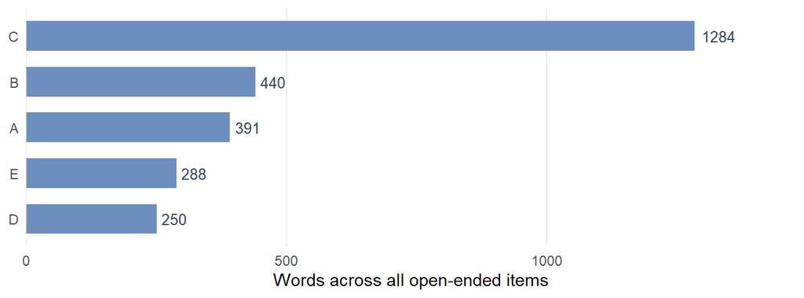

Figure 1: Open-ended word count by respondent.

**Note**

The questions that participants did not answered were implemented using Display Logic; these are not missing data.

## 1.1 The five respondents

Five people is few enough to hold in mind individually, and the themes that follow are easier to judge if you already know whose voice is carrying each one. Each respondent is sketched below as a **persona** — a compact reading of the perspective they took across the survey questions.

**WarningThese are reading aids, not a typology**

A persona here is a summary of *one person’s* answers. It is not a segment, validated type, or evidence that such a person recurs in the population.

### 1.1.1 A — The Keepsake Keeper

*Continuation is sensory, tied to specific shared episodes.*

391 words · 19 min · 19 of 24 open-ends · classification: 8 life, 11 both, 0 after, 1 not meaningful

Builds the entire account from one relationship - their grandmother - and the household objects that carry the individual. Meaning is episodic: an object is imbued with meaning because specific events happened around it, often repeatedly. Generic possessions and digital material are explicitly excluded. Dismisses money and property as legacy outright, and locates the meaningful part of planning in conversation and farewell rather than in the document. The fastest completion of the five, and the most internally consistent.

I have the dining room table that our family met at for Sunday dinners from the time I was a baby. Eating at that table is as close as we can get to having dinner with her.— A · `Q3`

### 1.1.2 B — The Inheritor

*What is passed down carries the person’s spirit; objects are how the spirit is preserved and continued physically.*

440 words · 27 min · 19 of 24 open-ends · classification: 2 life, 17 both, 1 after, 0 not meaningful

You can feel that person's soul inhabiting whatever it is that they've passed down. They are still present and speaking to you from beyond.— B · `Q3`

### 1.1.3 C — The Intellectual Heir

*Bodies perish but ideas do not - and the self that continues should be edited.*

1,284 words · 51 min · 20 of 24 open-ends · classification: 6 life, 9 both, 3 after, 0 not meaningful

Discusses a public figure (Albert Einstein) rather than a relative, and reasons about continuation as intellectual inheritance in both directions: what they received, and what they intend to leave. Rejects physical material explicitly. Performs the most demanding operation in the file - separating a person’s contribution (intellectually) from their conduct (e.g., moral behaviors) - and then applies the same edit to themselves. Wrote almost half of all open-ended text and is the only respondent to use *depends* or *unsure* in the classification task, so several themes below lean heavily on this one voice.

I believe that we are more sentient than flesh. What comes from our body is perishable, but not our thoughts and ideas. Those are more immortal in my opinion.— C · `Q5`

### 1.1.4 D — The Character Steward

*What continues is a moral disposition or perspective.*

250 words · 58 min · 16 of 24 open-ends · classification: 2 life, 6 both, 6 after, 6 not meaningful

Continuation is a transmitted disposition or perspective - seeing good in people, forgiveness, compassion - received from someone loved and passed onward. Rejected six of the twenty classification items, and every rejection was public, achievement-based, or externally recorded; nothing intimate was ever rejected. Wrote the least text but took the longest to do it.

I have continued to see the good in people despite what they do to me or anyone around me. This persistent feeling to forgive has grown stronger in me over the years.— D · `Q1.1`

### 1.1.5 E — The Provider

*What you leave has to reach people, and it has to be usable or help the surviving individuals.*

288 words · 55 min · 19 of 24 open-ends · classification: 9 life, 0 both, 11 after, 0 not meaningful

Discussed a case of broadcasted continuation (Ozzy Osbourne’s music). What matters about an inheritance is that it converts into subsistence for the people who survive you. The only respondent who never used *both* in the classification task, splitting all twenty items into either-or.

I'd like my family to have a much better life.— E · `Q9.1`

### 1.1.6 How the five differ at a glance

Table 2: The five respondents at a glance.

| ID | Persona | Position taken | Words |
| --- | --- | --- | --- |
| A | The Keepsake Keeper | Continuation is sensory, tied to specific shared episodes. | 391 |
| B | The Inheritor | What is passed down carries the person's spirit; objects are how the spirit is preserved and continued physically. | 440 |
| C | The Intellectual Heir | Bodies perish but ideas do not - and the self that continues should be edited. | 1284 |
| D | The Character Steward | What continues is a moral disposition or perspective. | 250 |
| E | The Provider | What you leave has to reach people, and it has to be usable or help the surviving individuals. | 288 |

# 2 Themes in Participant Responses

Seven candidate themes were pulled from the data.

## 2.1 Continuation runs through two different channels

Respondents describe continuation either as **intimate and relational** — carried by people who knew the deceased, experienced through daily sensory reminders — or as **impersonal and broadcasted** — carried by work or artifacts that reach people who never knew the person individually.

The relational channel is highly sensory and personal:

Sometimes it's a certain smell that reminds me of Sunday dinners, a memory, the thought of "what would she think of this?", and her keepsakes that are throughout my home.— A · `Q1.1`

The broadcast channel is explicitly indifferent to acquaintance, and one respondent frames it in terms of sheer reach and low access cost:

The only thing people need to listen to his music is an internet connection and a smart phone. He died not long ago but hundreds of millions of people still get on the internet and listen to his music every day.— E · `Q1.1`

What is interesting about him, is that everyone presents children as their legacy, yet I don't know who any of his children are but I do know a great deal about his work.— C · `Q1.1`

That last quote is the most theoretically loaded sentence in the file: it sets **biological continuation against intellectual continuation** (the context is Albert Einstein) and observes that the culturally standard answer (children) failed to continue whereas work succeeded to continue. The respondent returns to it unprompted at Q5, which suggests it is a stable perspective held rather than an offhand remark.

## 2.2 Meaning attaches to the remembered episode, not necessarily the object

Across Q3 and Q4 the same rule appears from both directions. An object carries the person when it is tied to a specific, repeated, shared episode. The object serves as a physical reminder of those events:

I have the dining room table that our family met at for Sunday dinners from the time I was a baby. Eating at that table is as close as we can get to having dinner with her.— A · `Q3`

And it fails to carry the person when nothing particular happened around it:

If the object did not have any specific memories attached, or was just something "general" it would not have a connection...such as a TV or telephone.— A · `Q4`

One participant discusses “continuation” as an opposing-valenced concept to “contagion.” For example, reminders of an unknown previous owner can make an inherited object actively aversive rather than merely neutral:

What comes to mind are houses and apartments. I don't know who lived in my current apartment, so if something was left behind I throw it out, however may people likely inhabited place prior to when I arrived. In fact if something was left behind and I don't know the person it feels icky and I don't want to keep it.— C · `Q4`

These passages suggest that people distinguish between **neutral** (a TV) and **contaminated** (a stranger’s leftovers) objects.

**Note**

This theme rests on `A` and `C`. `E` answered Q4 by restating the stem (“The object not feeling personally meaningful.”), and `D` answered in terms of an object’s *function* being exhausted rather than its social meaning — “A possession may become meaningless to the owner if it has already served its purpose or lost its value.” — which is arguably a different construct and should not be coded into this theme.

## 2.3 Different folk theories of what gets continued

You can feel that person's soul inhabiting whatever it is that they've passed down. They are still present and speaking to you from beyond.— B · `Q3`

Once a person gets rid of something that was passed on from that person it no longer carries the energy of that person.— B · `Q4`

If people can feel my spirit in whatever it is that they're doing and feel connected to me in some way.— B · `Q10`

Another explicitly rejects material possessions and locates continuation in ideas, using the language of perishability and immortality:

I believe that we are more sentient than flesh. What comes from our body is perishable, but not our thoughts and ideas. Those are more immortal in my opinion.— C · `Q5`

Both are theories about what gets left behind, and they make different predictions about estate planning: an animistic view makes the physical transfer of specific objects in which the spirit is imbued essential (the energy is *in* the thing, and is destroyed if the object is discarded), whereas an ideational view makes objects largely irrelevant and puts the weight on publication, testimony, and instruction. This distinction may be useful when considering the perspective’s role in EP engagement.

## 2.4 Continuation is curated and defined, not transferred in totality

People do not want all of themselves to continue. They want an **edited** version, and they are explicit about the editing.

Beyond all of my flaws, I would want my work to represent the best parts of me seperate from my falws. This carries the best part of who I am.— C · `Q10`

The same respondent applies the identical operation to Einstein — separating the contribution from the person — and articulates the moral rule they are using. This kind of reminds me of the moral decoupling phenomenon (Battacharjee et al. 2013), but a greater extent of decoupling may occur posthumously:

I don't think he treated women well... I have to detach that image I have of him and I focus on the subjects that matter to me the most. Although he has many parts, all of these parts do represent him as a whole, but that can be tricky. I find that is true for most people. We have to accept the good with the bad, but not excuse the negative parts of that person.— C · `Q3`

And curation extends to resisting a category one expects to be remembered *by*:

I don't want people to remember me as just being a "woman". I want to be remembered as someone who contributed to society and was sincere with pure intentions.— C · `Q9.1`

This theme is carried almost entirely by one respondent, so treat it as a hypothesis rather than a finding. It is nonetheless the clearest candidate for a new item: **the extended self appears to be selectively edited, and people have views about who is entitled to do the editing.**

## 2.5 What people think others want ≠ what they want themselves

Q5 asks what people *in general* care about leaving behind. Q9.1 asks what *you* want remembered. The two produce noticeably different content.

Q5 answers skew material and familial — possessions, homes, cars, debt, inheritance, children:

Their families, their homes, cars or other worldly possessions. They also want to make sure there is no debt left behind by them as well.— B · `Q5`

They're family, friends and pets. Also who inherits what of their possessions.— E · `Q5`

Q9.1 answers skew to character, contribution, and example:

My love of music, sense of justice and always fighting for what's right.— B · `Q9.1`

I want to be remembered as an intellect, someone who was kind and did alot for humanity.— C · `Q9.1`

One respondent makes the asymmetry into an explicit value judgment, and dismisses the material answer as a failure of living:

Sure, your money and property (if you had any) will be left behind, but if that is both your legacy and memory, did you ever live?— A · `Q5`

**TipPotential leads**

An interesting self-other difference here. A third-person framing may cue a legal/estate schema while the first-person framing cues a moral/character schema.

## 2.6 Planning is understood as legal instruments; meaning sits outside them

Q12 asks what plans come to mind. The answers are near-uniform and almost purely instrumental — wills, trusts, medical directives, funeral and cremation arrangements:

Creating a will— A · `Q12`

Living Trust, Will and Medical Directive— B · `Q12`

Will Estate Planning Cremation Funeral— C · `Q12`

1. Burial arrangements 2. Writing a will 3. Telling a final wish.— D · `Q12`

Wills.— E · `Q12`

Q13 then asks which of those feel connected to *continuation* as opposed to being merely administrative. 4 of 5 respondents never leave the list they just gave, and one of them says so explicitly — the distinction the item is trying to draw largely did not land (see Section 5).

The one respondent who names something outside the list of instruments relocates meaning **into a communicative act**, and a second does the same when Q16 asks what would make planning feel meaningful:

Having the conversation about life, death, after, and legacy— A · `Q13`

Having the opportunity to say anything that you needed to and close up any loose ends. Saying goodbye in your own way.— A · `Q16`

I would so it is personally meaningful if I am cremated, and I want to leave behind ideas for others to read and respond to at my ceremony.— C · `Q16`

The pattern across Q13 and Q16 is that legal instruments are seen as protecting and directing assets, while *meaning* is attributed to conversation, farewell, and leaving words to be read aloud. That is a directly actionable finding: the felt gap between “administrative” and “personally meaningful” planning is filled by **speech acts, not better paperwork.**

**TipPotential leads**

A manipulation we could consider is stating that estate planning serves as a starting point for such conversations. It stimulates communication, which is more meaningful to people.

## 2.7 Plans connect to the person through custody and protection

When asked what creates the link between a plan and the person (Q14), respondents converge on stewardship — the right things reaching the right hands, and dependents being shielded from burden.

The person is the one mapping out how they want everything to go and be distributed. So it's leaving what they care about the most in the hands that they trust the most.— B · `Q14`

The sole desire to know that what was labored for is in good hands is a great connection.— D · `Q14`

These plans definitely protect family members from financial burden. I think it is important to have a form of life insuance. I think leaving behind a will to state what you want and do not want are very important because you can preserve what you want others to remember.— C · `Q14`

The recurring phrase is *hands* — “the hands that they trust the most,” “in good hands,” and at Q10 “in the right hands and getting proper care.” Continuation is framed as a **custody transfer to a trusted party**, with the trustworthiness of the recipient, not the value of the asset, doing the work.

# 3 The classification exercise

Twenty items, each classified as meaningful **during life**, **after death**, **during both**, **generally not meaningful to carry forward**, **it depends**, or **unsure**.

Codes 4–6 are a rejection, a conditional, and a non-answer; they are counted separately and never mixed into anything else. Only 9 of 100 responses fell off-scale.

**Important“Both” is a category, not a midpoint**

*Meaningful during both* is an endorsement of **both** periods at once, not a weak or neutral position between them. Treating it as the middle of a single scale would put an item that everyone agrees matters in both periods in the same place as an item respondents split evenly over — two opposite situations.

So each period gets its **own** endorsement rate, and the two are independent:

| **Life relevance** | share endorsing *during life* — codes **1 or 3** |
| --- | --- |
| **Posthumous relevance** | share endorsing *after death* — codes **2 or 3** |
| **Asymmetry** | posthumous − life relevance. *Both* carries no direction and cancels out, so this is the only directional claim the data supports. |

An item can be high on both measures; that is what a *both*-heavy item looks like, and it is a substantive result rather than a wash.

## 3.1 Dual relevance is the most common answer

Before any ordering, the single largest fact in this table is how often respondents refused the either-or:

Table 3: How the 100 classification responses were distributed across the six options.

| Answer | Responses | Share |
| --- | --- | --- |
| Meaningful during life | 27 | 27% |
| Meaningful after death | 21 | 21% |
| Meaningful during both | 43 | 43% |
| Generally not meaningful | 7 | 7% |
| It depends | 1 | 1% |
| Unsure | 1 | 1% |

**43% of all responses were *both***, more than either single-period answer. Whatever else the classification task shows, the modal view is that these things are **not** exclusively posthumous: continuation is mostly seen as something already underway during life that carries on, rather than a state that begins at death.

That reframes what the item ordering below is measuring. Almost nothing is purely one or the other — no item was placed after-death-only by everyone, and none was placed life-only by everyone either. The question separating the items is not *when does this matter* but **what survives**.

## 3.2 What each period gets endorsed for

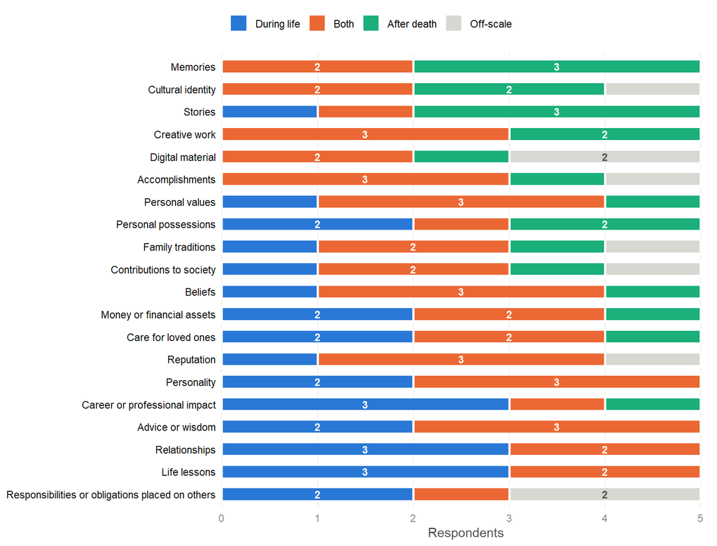

Figure 2: How all five respondents classified each item, ordered by asymmetry (posthumous minus life relevance). Every bar totals five responses; the pale segment is off-scale (not meaningful, depends, unsure). Counts are labelled where a segment covers two or more respondents.

Read top to bottom, the orange *both* band is present in every row: no item drew zero *both* responses, and only 4 of 20 drew fewer than two (responsibilities or obligations placed on others, career or professional impact, personal possessions, stories). The ordering still separates two ends, but what it separates is now stated more carefully:

At the life end sit **relationships, life lessons, advice, personality, career impact** — things that are *enacted*, that exist in the doing. At the posthumous end sit **memories, cultural identity, creative work, stories, digital material** — things that can persist as a *record*. That is the same enacted/trace distinction that separated the two continuation channels in Section 2.1 and the two folk theories in Section 2.3, arrived at independently through a closed-format task.

But the corrected measures show the asymmetry is one-sided in a way the earlier framing hid:

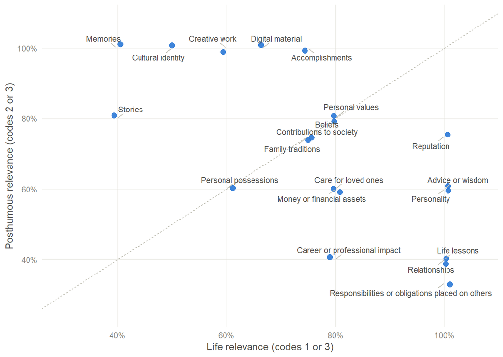

Figure 3: Life relevance against posthumous relevance. Points on the dashed line are endorsed equally for both periods; distance up-and-right means an item is widely endorsed for both at once, which is what a ‘both’-heavy item looks like. Points are jittered slightly so ties remain visible.

**Money is endorsed more for life than for death** (life 80%, posthumous 60%). The single most standard bequest item is *not* read as primarily posthumous. That fits the open-ended data, where `A` dismissed money as a legacy outright and `E` framed inheritance as provisioning for the living. For an estate-planning study this is a substantive finding, not noise.

# 4 All responses, organized two ways

The complete text, laid out twice. Read it **by question** to compare what five people said to the same prompt; read it **by respondent** to check that an idea is a coherent position rather than an artifact of how one question was worded.

## 4.1 Question by question

Every open-ended item with all responses side by side, in item order. Items are grouped by the stage of the instrument they belong to; each question’s full wording appears above its responses.

### 4.1.1 Continuation in others

Q1.1How that person continues to affect peopleHow does this person continue to affect people? Please describe what seems to continue about the person and how that continuing effect is experienced.

The person I am thinking of is my Grandmother. There are many almost daily reminders of her life. Sometimes it's a certain smell that reminds me of Sunday dinners, a memory, the thought of "what would she think of this?", and her keepsakes that are throughout my home. While she has passed, it allows her memory to stay with us.A · 60 words

This person has taught me that this world will never be for me and he has appreciated me for figuring out a way to move through it. He has always taught me to beware of the pitfalls of life but also to protect myself at all times in this life. Every day I think about something he taught me that still holds true and will remain as a life lesson. Life is not easy but I'm thankful that he gave me great advice to help me navigate it.B · 88 words

You asked us to be honest, so the first person who came to mind is Albert Einstein. I'm not fully sure if his contributions to science are fully his creation as I know his wife at the time contributed to his work. However, everyone remembers Einstein, his ideas and work are the foundation of certain subjects in science, physics and mathematics. What is interesting about him, is that everyone presents children as their legacy, yet I don't know who any of his children are but I do know a great deal about his work.C · 94 words

I have continued to see the good in people despite what they do to me or anyone around me. This persistent feeling to forgive has grown stronger in me over the years.D · 32 words

Ozzy Osbourne's music inspired early heavy metal and relieved alot of anxiety in listeners for decades and still continues to do so today. The only thing people need to listen to his music is an internet connection and a smart phone. He died not long ago but hundreds of millions of people still get on the internet and listen to his music every day.E · 64 words

Q1.2How a person might continue to affect others (if none came to mind)In general, how might a person continue to affect others after death? You may describe a real, public, or hypothetical example.

No responses. This item is gated on `Q1`; no respondent took that branch.

Q2.1What was passed on / received / experiencedWhat was passed on, received, remembered, or experienced? You may answer using your own experience, something you observed, or a hypothetical example.

When my Grandmother passed my father and I went trough all of her belongings and kept the things that met the most to her and us. It was nothing of great monetary value, but items that contained memories. My son has a few in his room, and others are displayed throughout my home.A · 53 words

I received the first intergenerational wealth transfer that my family had ever experienced through multiple facets, which has aided me in increasing and expanding on my familial wealth.B · 28 words

With Albert Einstein he has impacted many of us, and his findings are in modern education. For me personally, his work along with another mathematician inspired me to learn more about astro physics and time theory. There are some who are more passionate about him than I am. It does feel a great deal of his work has been passed on and it's interesting. You want to learn and build upon what he has already worked on, the same way he built upon or may potentially have been inspired by Isaac Newton.C · 92 words

The ability to see the good in everything was passed down to me.D · 13 words

Music and memories.E · 3 words

Q2.1aWhat made it feel connected to that personWhat made it feel connected to that person?

I was close to my grandmother growing up. I spent more time with her than I did my parents. The items that I kept are all related to specific memories I have with her.A · 34 words

The person who transferred it did it off of nearly 40 years of labor intensive work.B · 16 words

My background and education is primarily in applied and computational mathematics. He is one of the individuals who inspired me in the subjects of math and physics. I feel connected to him, purely through what he was working on and how he is one of the individuals who opened my mind to exploring time itself.C · 55 words

My love for her made me feel connected to her.D · 10 words

He was the lead singer of the music band that made the music.E · 13 words

Q2.2What might make someone feel connected (if no experience)What kinds of things, if any, might make someone feel connected to a person who has died?

No responses. This item is gated on `Q2`; no respondent took that branch.

### 4.1.2 What carries a person

Q3What makes something carry or represent part of a personSomething connected to a person who has died may feel deeply personal, mainly practical or material, or somewhere in between. What makes something feel as though it carries or represents part of a person?

I have the dining room table that our family met at for Sunday dinners from the time I was a baby. Eating at that table is as close as we can get to having dinner with her.A · 37 words

You can feel that person's soul inhabiting whatever it is that they've passed down. They are still present and speaking to you from beyond.B · 24 words

I'm more of a deep thinker. I never really cared about material things. It's deeply personal from an intelletual standpoint but not toward him as a whole. I don't think he treated women well... I have to detach that image I have of him and I focus on the subjects that matter to me the most. Although he has many parts, all of these parts do represent him as a whole, but that can be tricky. I find that is true for most people. We have to accept the good with the bad, but not excuse the negative parts of that person. No one is perfect, including myself. I think what matters is who we become in the end, and our journey to become a more evovled human being. The journey that we go through is what makes us who we are today and I am becoming less judgemental and more observant of people; this incudes historical figures such as Einstein.C · 161 words

I see myself showing so much compassion for helpless people.D · 10 words

Actions, possessions or thoughts related to the person.E · 8 words

Q4What makes an object NOT feel connected to its ownerA possession or object may have belonged to someone without feeling personally meaningful. What might cause an object or other possession not to feel connected to the person who owned it?

If the object did not have any specific memories attached, or was just something "general" it would not have a connection...such as a TV or telephone.A · 26 words

Once a person gets rid of something that was passed on from that person it no longer carries the energy of that person.B · 23 words

I don't know how to answer that... I feel that objects are connected to a person in a sense. I suppose what would cause an object to not feel connected to the person is if they hadn't owned it very long or it wasn't important to them. What just came to mind is, if I don't know the person or even know if they existed, than an object may not mean much in the sense of who it belonged to prior. What comes to mind are houses and apartments. I don't know who lived in my current apartment, so if something was left behind I throw it out, however may people likely inhabited place prior to when I arrived. In fact if something was left behind and I don't know the person it feels icky and I don't want to keep it. Objects do carry a vibe, but it could just be all in my mind.C · 156 words

A possession may become meaningless to the owner if it has already served its purpose or lost its value.D · 19 words

The object not feeling personally meaningful.E · 6 words

### 4.1.3 Naming the construct

Q5What people might care about leaving behindWhen people think about what might remain, continue, or be left behind after they die, what kinds of things might they care about? Please list as many different possibilities as naturally come to mind. These may be tangible or intangible. Brief words or phrases are fine.

I believe the only true thing that id left behind when we die is the memories and impressions that the person had made when they were living. Sure, your money and property (if you had any) will be left behind, but if that is both your legacy and memory, did you ever live?A · 53 words

Their families, their homes, cars or other worldly possessions. They also want to make sure there is no debt left behind by them as well.B · 25 words

I think most people want to procreate and leave behind children and that their children will have children. I myself, don't have children and don't have a desire to have children. I want people to remember me for my intelligence and contributions to the world. I believe that people want to leave behind some form of wealth, something that their children can use to leave behind. Remember, I stated earlier that I have no idea nor do I know the names of any of Einstein's children. There are many ways to leave behind a legacy, and how to continue on. I believe that we are more sentient than flesh. What comes from our body is perishable, but not our thoughts and ideas. Those are more immortal in my opinion.C · 129 words

1. Their memories continue to live on. 2. They may leave some possessions. 3. Their advice could stick in our heads.D · 21 words

They're family, friends and pets. Also who inherits what of their possessions.E · 12 words

Q6Words/phrases for something continuing after deathWhat words or phrases would you use to describe the idea that something about a person remains, continues, or is carried forward after the person has died? Please use whatever language comes naturally to you.

memoryA · 1 words

Family, homes, debt, material items.B · 5 words

The words and phrases I would use to describe this concept is that humans leave behind ideas, the impact and words they shared with others. They leave behind their accomplishments. All of the actions we took in between are what is remembered. Words that come to mind Legacy Success Kindness Trauma Religion ImpactC · 53 words

I could use the word legacy.D · 6 words

Thoughts and inheritence.E · 3 words

Q7Whether those words mean different thingsIf you listed more than one word or phrase, do they mean different things to you? For example, two words may seem similar but may not describe exactly the same idea. Please describe any differences that seem important.

I only left one word. memory.A · 6 words

I guess debt could mean a home too if a mortgage is carried and any other material items that have a note.B · 22 words

Absolutely! All of the words can potentially overlap in some way, but they are all different. For example success is subjective. Some may consider having children, earning lots of money or being a good person is "success".C · 37 words

**D** — not shown or left blank

Yes. Thoughts are not like inheritance for the most part unless it's a thought of the asset in the inheritance. Then they're more alike.E · 24 words

### 4.1.4 The self, carried forward

Q8.1Aspects carried forward while aliveWhat aspects of yourself do you try or hope to carry forward while you are alive?

I am not really sure what this means. I hope to continue to do my best to be a good example for my child, a good father, husband, and person.A · 30 words

I hope that my sense of justice and doing what's always right carries forward to those who love me.B · 19 words

I want to carry forward being a good person. There are times that I haven't been as good as I should have been. I want the impact that I have on other people to be positive and one that makes their life better. I want to also leave behind intellectual legacy, I would like to contribute to science and technology.C · 60 words

I hope to carry my kindness along as I live on because the world is becoming scarier by the day, and people can put you on edge sometimes.D · 28 words

I'd like to end world hunger and get cures for all the diseases main stream. Not just for people but animals and the environment too.E · 25 words

Q9.1What should remain / be rememberedWhat would you want to remain, continue, or be remembered?

Hopefully I will be remembered well for what I did while I was here.A · 14 words

My love of music, sense of justice and always fighting for what's right.B · 13 words

I want to be remembered as an intellect, someone who was kind and did alot for humanity. I don't want people to remember me as just being a "woman". I want to be remembered as someone who contributed to society and was sincere with pure intentions.C · 46 words

**D** — not shown or left blank

I'd like my family to have a much better life.E · 10 words

Q9.1aHow it might continue and why it mattersHow might it continue, and why would that matter to you?

With my sons memory. I hope I gave a good example.A · 11 words

It might continue through an organization that I belong to that I've always cared about and through the people in that organization. It will also carry on through my family and friends that love me.B · 35 words

I'm not sure how it might continue as I don't feel as of yet that I have done what I set out to do, atleast not completely or in a way that is impactful. I'm not sure why it matters to me, and I've been working on making sure that my energy is sincere. I don't want it to be for vain reasons, but pure intent.C · 66 words

**D** — not shown or left blank

The world becoming a better place and my family making smarter decisions about their future. I love my family. I'd take a bullet for anybody in my family.E · 28 words

Q10What makes continuation feel genuinely representativeImagine that something connected to you continues after your death. What would make it feel as though it genuinely represented or carried part of you, rather than simply existing after your death?

My families success and happiness. period.A · 6 words

If people can feel my spirit in whatever it is that they're doing and feel connected to me in some way.B · 21 words

My ideas including my creative ideas, and scientific ideas I feel geniunely represent who I am or atleast who I wanted to be. Beyond all of my flaws, I would want my work to represent the best parts of me seperate from my falws. This carries the best part of who I am.C · 53 words

Something I left could feel that way if I know it is in the right hands and getting proper care.D · 20 words

PIctures of me because I look like what's in the pictures.E · 11 words

Q11.1What should NOT continue, and whyWhat would you prefer not to have continued, passed on, or remembered, and why?

No responses. This item is gated on `Q11`; no respondent took that branch.

### 4.1.5 Planning

Q12Formal/informal plans that come to mindWhat kinds of formal or informal plans come to mind when you think about preparing for what will happen after a person dies? Please list whatever naturally comes to mind. Brief words or phrases are acceptable.

Creating a willA · 3 words

Living Trust, Will and Medical DirectiveB · 6 words

Will Estate Planning Cremation FuneralC · 5 words

1. Burial arrangements 2. Writing a will 3. Telling a final wish.D · 12 words

Wills.E · 1 words

Q13Which plans feel connected to continuationSome plans may feel connected to helping something about a person continue after death. Other plans may feel mainly practical, legal, administrative, or financial. Which kinds of plans, if any, feel connected to continuing something about the person?

Having the conversation about life, death, after, and legacyA · 9 words

Living Trust, Will and Medical DirectiveB · 6 words

Financial is part ofi it, I listed most of those previously as that what comes to mind. The financial is a way for others to benefit from the previous person's wealth but also their debt. It may be a reminder of how good they were with finances or the burdens they've left behind. The cremation or funeral plans are important, if the person wants to leave behind certain ideas to be said at their funeral and to also protect family members from financial burden should they pass away.C · 88 words

I think writing a will feels connected to continuing something after a person dies.D · 14 words

Making wills.E · 2 words

Q14What creates the connection between plans and personWhat creates the connection between those plans and the person? For example, you might consider what the plan expresses, protects, passes on, preserves, or makes possible.

Protects that persons belongings, ensuring the go where desired.A · 9 words

The person is the one mapping out how they want everything to go and be distributed. So it's leaving what they care about the most in the hands that they trust the most.B · 33 words

These plans definitely protect family members from financial burden. I think it is important to have a form of life insuance. I think leaving behind a will to state what you want and do not want are very important because you can preserve what you want others to remember.C · 49 words

The sole desire to know that what was labored for is in good hands is a great connection.D · 18 words

The person that is dying's family or the person that will die making their will.E · 15 words

Q15How wanting continuation affects willingness to planHow, if at all, might wanting some part of oneself to continue after death affect a person's willingness to make plans for what happens afterward? It might make planning feel easier, harder, more important, less important, more meaningful, less meaningful, or have no effect. Please explain your answer.

Depending on the situation it could be easier or harder at that moment.A · 13 words

I can only think of multiple siblings existing to where it's too hard to figure out how to distribute everything so you would rather it just go through Probate. If the Trust is created it does signify that you want to make things easier for your loved ones and that you've put actual thought into it that can't be challenged.B · 60 words

This question is worded in a strange way... Based on my interpretation, perhaps a person may not want to lie to others and may have kept secrets so they hold off on making certain plans as that may expose certain things they don't want others to know just yet.C · 49 words

Personally, I think that it makes it easier to continue after death, because you are sure of who you are leaving your possessions for.D · 24 words

They would adjust their will accordingly to what happens to stuff connected to them after they die.E · 17 words

Q16What makes planning feel personally meaningfulWhat would make planning for what happens after death feel personally meaningful rather than mainly legal, administrative, or financial?

Having the opportunity to say anything that you needed to and close up any loose ends. Saying goodbye in your own way.A · 22 words

If everyone respected my wishes and understood exactly how I would want things done.B · 14 words

I would so it is personally meaningful if I am cremated, and I want to leave behind ideas for others to read and respond to at my ceremony.C · 28 words

I think leaving a legacy for your family, friends, or someone very close could be very meaningful.D · 17 words

Knowing the inheriter of the inheritance will have something valuable and worth money which can be sold or traded for food or something the inheriter needs to keep living.E · 29 words

### 4.1.6 Classification exercise and closing

Sort.1What 'it depends on the situation' depends onIf, for one or more items, you selected "It depends on the situation," what does the significance of carrying these things forward depend on? You may discuss none, one, or several items.

n/aA · 1 words

N/AB · 1 words

Cultural identity is a social construct, it matters but it depends on the traditions and values of that person and the people around them.C · 24 words

noneD · 1 words

I didn't select any "It depends on the situation".E · 9 words

Sort.2aWhat should have been includedWhat should have been included?

No responses. This item is gated on `Sort.2`; no respondent took that branch.

Q17Other thoughts not covered earlierDo you have any other thoughts about what a person leaves behind or how something about a person might continue after death? Please share anything that you feel was not covered by the earlier questions.

I do notA · 3 words

No.B · 1 words

You've asked a lot of great questions and I feel I've expressed my ideas in detail.C · 16 words

**D** — not shown or left blank

**E** — not shown or left blank

Q18Feedback about the surveyDo you have any feedback about this survey? For example, you may comment on: questions that were unclear, questions that seemed repetitive, important ideas that were missing, parts that felt emotionally difficult, the length of the survey, or problems with how the survey appeared on your device.

**A** — not shown or left blank

**B** — not shown or left blank

The open ended questions I became lost in and it took a lot longer than intended. Otherwise, it was a great thought exercise.C · 23 words

The survey questions were clear.D · 5 words

Good survey and high pay. Thanks a ton.E · 8 words

## 4.2 Respondent by respondent

The same data read the other way — one person end to end.

**WarningDemographics are unlabelled**

The export contains **numeric choice codes**, not labels, for `age`, `gender`, `education`, `employment`, and `hhi`. They are printed below exactly as exported and are not interpretable yet. Add a value-label lookup here once you have the codebook — until then, do not read `age: 4` as anything in particular. Free-text fields such as `state` and `relationship` come through as written.

### 4.2.1 A — The Keepsake Keeper

391 words across 19 open-ended items · 19.2 minutes · `R_3KH2YTGHcRTce9Y`  
**age:** 11 · **gender:** 2 · **education:** 2 · **employment:** 1 · **income:** 4 · **state:** Maryland · **children:** 1 · **relationship:** Married

The person I am thinking of is my Grandmother. There are many almost daily reminders of her life. Sometimes it's a certain smell that reminds me of Sunday dinners, a memory, the thought of "what would she think of this?", and her keepsakes that are throughout my home. While she has passed, it allows her memory to stay with us.Q1.1 · How that person continues to affect people

When my Grandmother passed my father and I went trough all of her belongings and kept the things that met the most to her and us. It was nothing of great monetary value, but items that contained memories. My son has a few in his room, and others are displayed throughout my home.Q2.1 · What was passed on / received / experienced

I was close to my grandmother growing up. I spent more time with her than I did my parents. The items that I kept are all related to specific memories I have with her.Q2.1a · What made it feel connected to that person

I have the dining room table that our family met at for Sunday dinners from the time I was a baby. Eating at that table is as close as we can get to having dinner with her.Q3 · What makes something carry or represent part of a person

If the object did not have any specific memories attached, or was just something "general" it would not have a connection...such as a TV or telephone.Q4 · What makes an object NOT feel connected to its owner

I believe the only true thing that id left behind when we die is the memories and impressions that the person had made when they were living. Sure, your money and property (if you had any) will be left behind, but if that is both your legacy and memory, did you ever live?Q5 · What people might care about leaving behind

memoryQ6 · Words/phrases for something continuing after death

I only left one word. memory.Q7 · Whether those words mean different things

I am not really sure what this means. I hope to continue to do my best to be a good example for my child, a good father, husband, and person.Q8.1 · Aspects carried forward while alive

Hopefully I will be remembered well for what I did while I was here.Q9.1 · What should remain / be remembered

With my sons memory. I hope I gave a good example.Q9.1a · How it might continue and why it matters

My families success and happiness. period.Q10 · What makes continuation feel genuinely representative

Creating a willQ12 · Formal/informal plans that come to mind

Having the conversation about life, death, after, and legacyQ13 · Which plans feel connected to continuation

Protects that persons belongings, ensuring the go where desired.Q14 · What creates the connection between plans and person

Depending on the situation it could be easier or harder at that moment.Q15 · How wanting continuation affects willingness to plan

Having the opportunity to say anything that you needed to and close up any loose ends. Saying goodbye in your own way.Q16 · What makes planning feel personally meaningful

n/aSort.1 · What 'it depends on the situation' depends on

I do notQ17 · Other thoughts not covered earlier

### 4.2.2 B — The Inheritor

440 words across 19 open-ended items · 27.2 minutes · `R_7waIqXwPECP3UNt`  
**age:** 4 · **gender:** 1 · **education:** 4 · **employment:** 1 · **income:** 4 · **state:** California · **children:** 2 · **relationship:** Sing, never married.

This person has taught me that this world will never be for me and he has appreciated me for figuring out a way to move through it. He has always taught me to beware of the pitfalls of life but also to protect myself at all times in this life. Every day I think about something he taught me that still holds true and will remain as a life lesson. Life is not easy but I'm thankful that he gave me great advice to help me navigate it.Q1.1 · How that person continues to affect people

I received the first intergenerational wealth transfer that my family had ever experienced through multiple facets, which has aided me in increasing and expanding on my familial wealth.Q2.1 · What was passed on / received / experienced

The person who transferred it did it off of nearly 40 years of labor intensive work.Q2.1a · What made it feel connected to that person

You can feel that person's soul inhabiting whatever it is that they've passed down. They are still present and speaking to you from beyond.Q3 · What makes something carry or represent part of a person

Once a person gets rid of something that was passed on from that person it no longer carries the energy of that person.Q4 · What makes an object NOT feel connected to its owner

Their families, their homes, cars or other worldly possessions. They also want to make sure there is no debt left behind by them as well.Q5 · What people might care about leaving behind

Family, homes, debt, material items.Q6 · Words/phrases for something continuing after death

I guess debt could mean a home too if a mortgage is carried and any other material items that have a note.Q7 · Whether those words mean different things

I hope that my sense of justice and doing what's always right carries forward to those who love me.Q8.1 · Aspects carried forward while alive

My love of music, sense of justice and always fighting for what's right.Q9.1 · What should remain / be remembered

It might continue through an organization that I belong to that I've always cared about and through the people in that organization. It will also carry on through my family and friends that love me.Q9.1a · How it might continue and why it matters

If people can feel my spirit in whatever it is that they're doing and feel connected to me in some way.Q10 · What makes continuation feel genuinely representative

Living Trust, Will and Medical DirectiveQ12 · Formal/informal plans that come to mind

Living Trust, Will and Medical DirectiveQ13 · Which plans feel connected to continuation

The person is the one mapping out how they want everything to go and be distributed. So it's leaving what they care about the most in the hands that they trust the most.Q14 · What creates the connection between plans and person

I can only think of multiple siblings existing to where it's too hard to figure out how to distribute everything so you would rather it just go through Probate. If the Trust is created it does signify that you want to make things easier for your loved ones and that you've put actual thought into it that can't be challenged.Q15 · How wanting continuation affects willingness to plan

If everyone respected my wishes and understood exactly how I would want things done.Q16 · What makes planning feel personally meaningful

N/ASort.1 · What 'it depends on the situation' depends on

No.Q17 · Other thoughts not covered earlier

### 4.2.3 C — The Intellectual Heir

1284 words across 20 open-ended items · 51.4 minutes · `R_6SIoawXhIRvDtLz`  
**age:** 4 · **gender:** 1 · **education:** 5 · **employment:** 3 · **income:** 3 · **state:** North Carolina · **children:** 2 · **relationship:** I am single, never married.

You asked us to be honest, so the first person who came to mind is Albert Einstein. I'm not fully sure if his contributions to science are fully his creation as I know his wife at the time contributed to his work. However, everyone remembers Einstein, his ideas and work are the foundation of certain subjects in science, physics and mathematics. What is interesting about him, is that everyone presents children as their legacy, yet I don't know who any of his children are but I do know a great deal about his work.Q1.1 · How that person continues to affect people

With Albert Einstein he has impacted many of us, and his findings are in modern education. For me personally, his work along with another mathematician inspired me to learn more about astro physics and time theory. There are some who are more passionate about him than I am. It does feel a great deal of his work has been passed on and it's interesting. You want to learn and build upon what he has already worked on, the same way he built upon or may potentially have been inspired by Isaac Newton.Q2.1 · What was passed on / received / experienced

My background and education is primarily in applied and computational mathematics. He is one of the individuals who inspired me in the subjects of math and physics. I feel connected to him, purely through what he was working on and how he is one of the individuals who opened my mind to exploring time itself.Q2.1a · What made it feel connected to that person

I'm more of a deep thinker. I never really cared about material things. It's deeply personal from an intelletual standpoint but not toward him as a whole. I don't think he treated women well... I have to detach that image I have of him and I focus on the subjects that matter to me the most. Although he has many parts, all of these parts do represent him as a whole, but that can be tricky. I find that is true for most people. We have to accept the good with the bad, but not excuse the negative parts of that person. No one is perfect, including myself. I think what matters is who we become in the end, and our journey to become a more evovled human being. The journey that we go through is what makes us who we are today and I am becoming less judgemental and more observant of people; this incudes historical figures such as Einstein.Q3 · What makes something carry or represent part of a person

I don't know how to answer that... I feel that objects are connected to a person in a sense. I suppose what would cause an object to not feel connected to the person is if they hadn't owned it very long or it wasn't important to them. What just came to mind is, if I don't know the person or even know if they existed, than an object may not mean much in the sense of who it belonged to prior. What comes to mind are houses and apartments. I don't know who lived in my current apartment, so if something was left behind I throw it out, however may people likely inhabited place prior to when I arrived. In fact if something was left behind and I don't know the person it feels icky and I don't want to keep it. Objects do carry a vibe, but it could just be all in my mind.Q4 · What makes an object NOT feel connected to its owner

I think most people want to procreate and leave behind children and that their children will have children. I myself, don't have children and don't have a desire to have children. I want people to remember me for my intelligence and contributions to the world. I believe that people want to leave behind some form of wealth, something that their children can use to leave behind. Remember, I stated earlier that I have no idea nor do I know the names of any of Einstein's children. There are many ways to leave behind a legacy, and how to continue on. I believe that we are more sentient than flesh. What comes from our body is perishable, but not our thoughts and ideas. Those are more immortal in my opinion.Q5 · What people might care about leaving behind

The words and phrases I would use to describe this concept is that humans leave behind ideas, the impact and words they shared with others. They leave behind their accomplishments. All of the actions we took in between are what is remembered. Words that come to mind Legacy Success Kindness Trauma Religion ImpactQ6 · Words/phrases for something continuing after death

Absolutely! All of the words can potentially overlap in some way, but they are all different. For example success is subjective. Some may consider having children, earning lots of money or being a good person is "success".Q7 · Whether those words mean different things

I want to carry forward being a good person. There are times that I haven't been as good as I should have been. I want the impact that I have on other people to be positive and one that makes their life better. I want to also leave behind intellectual legacy, I would like to contribute to science and technology.Q8.1 · Aspects carried forward while alive

I want to be remembered as an intellect, someone who was kind and did alot for humanity. I don't want people to remember me as just being a "woman". I want to be remembered as someone who contributed to society and was sincere with pure intentions.Q9.1 · What should remain / be remembered

I'm not sure how it might continue as I don't feel as of yet that I have done what I set out to do, atleast not completely or in a way that is impactful. I'm not sure why it matters to me, and I've been working on making sure that my energy is sincere. I don't want it to be for vain reasons, but pure intent.Q9.1a · How it might continue and why it matters

My ideas including my creative ideas, and scientific ideas I feel geniunely represent who I am or atleast who I wanted to be. Beyond all of my flaws, I would want my work to represent the best parts of me seperate from my falws. This carries the best part of who I am.Q10 · What makes continuation feel genuinely representative

Will Estate Planning Cremation FuneralQ12 · Formal/informal plans that come to mind

Financial is part ofi it, I listed most of those previously as that what comes to mind. The financial is a way for others to benefit from the previous person's wealth but also their debt. It may be a reminder of how good they were with finances or the burdens they've left behind. The cremation or funeral plans are important, if the person wants to leave behind certain ideas to be said at their funeral and to also protect family members from financial burden should they pass away.Q13 · Which plans feel connected to continuation

These plans definitely protect family members from financial burden. I think it is important to have a form of life insuance. I think leaving behind a will to state what you want and do not want are very important because you can preserve what you want others to remember.Q14 · What creates the connection between plans and person

This question is worded in a strange way... Based on my interpretation, perhaps a person may not want to lie to others and may have kept secrets so they hold off on making certain plans as that may expose certain things they don't want others to know just yet.Q15 · How wanting continuation affects willingness to plan

I would so it is personally meaningful if I am cremated, and I want to leave behind ideas for others to read and respond to at my ceremony.Q16 · What makes planning feel personally meaningful

Cultural identity is a social construct, it matters but it depends on the traditions and values of that person and the people around them.Sort.1 · What 'it depends on the situation' depends on

You've asked a lot of great questions and I feel I've expressed my ideas in detail.Q17 · Other thoughts not covered earlier

The open ended questions I became lost in and it took a lot longer than intended. Otherwise, it was a great thought exercise.Q18 · Feedback about the survey

### 4.2.4 D — The Character Steward

250 words across 16 open-ended items · 57.9 minutes · `R_5lYWDAT678BA2sk`  
**age:** 11 · **gender:** 2 · **education:** 4 · **employment:** 1 · **income:** 5 · **state:** Indiana · **children:** 1 · **relationship:** Married

I have continued to see the good in people despite what they do to me or anyone around me. This persistent feeling to forgive has grown stronger in me over the years.Q1.1 · How that person continues to affect people

The ability to see the good in everything was passed down to me.Q2.1 · What was passed on / received / experienced

My love for her made me feel connected to her.Q2.1a · What made it feel connected to that person

I see myself showing so much compassion for helpless people.Q3 · What makes something carry or represent part of a person

A possession may become meaningless to the owner if it has already served its purpose or lost its value.Q4 · What makes an object NOT feel connected to its owner

1. Their memories continue to live on. 2. They may leave some possessions. 3. Their advice could stick in our heads.Q5 · What people might care about leaving behind

I could use the word legacy.Q6 · Words/phrases for something continuing after death

I hope to carry my kindness along as I live on because the world is becoming scarier by the day, and people can put you on edge sometimes.Q8.1 · Aspects carried forward while alive

Something I left could feel that way if I know it is in the right hands and getting proper care.Q10 · What makes continuation feel genuinely representative

1. Burial arrangements 2. Writing a will 3. Telling a final wish.Q12 · Formal/informal plans that come to mind

I think writing a will feels connected to continuing something after a person dies.Q13 · Which plans feel connected to continuation

The sole desire to know that what was labored for is in good hands is a great connection.Q14 · What creates the connection between plans and person

Personally, I think that it makes it easier to continue after death, because you are sure of who you are leaving your possessions for.Q15 · How wanting continuation affects willingness to plan

I think leaving a legacy for your family, friends, or someone very close could be very meaningful.Q16 · What makes planning feel personally meaningful

noneSort.1 · What 'it depends on the situation' depends on

The survey questions were clear.Q18 · Feedback about the survey

### 4.2.5 E — The Provider

288 words across 19 open-ended items · 54.5 minutes · `R_3CfMsBTPorUTjLS`  
**age:** 11 · **gender:** 2 · **education:** 2 · **employment:** 1 · **income:** 3 · **state:** Alabama · **children:** 2 · **relationship:** single

Ozzy Osbourne's music inspired early heavy metal and relieved alot of anxiety in listeners for decades and still continues to do so today. The only thing people need to listen to his music is an internet connection and a smart phone. He died not long ago but hundreds of millions of people still get on the internet and listen to his music every day.Q1.1 · How that person continues to affect people

Music and memories.Q2.1 · What was passed on / received / experienced

He was the lead singer of the music band that made the music.Q2.1a · What made it feel connected to that person

Actions, possessions or thoughts related to the person.Q3 · What makes something carry or represent part of a person

The object not feeling personally meaningful.Q4 · What makes an object NOT feel connected to its owner

They're family, friends and pets. Also who inherits what of their possessions.Q5 · What people might care about leaving behind

Thoughts and inheritence.Q6 · Words/phrases for something continuing after death

Yes. Thoughts are not like inheritance for the most part unless it's a thought of the asset in the inheritance. Then they're more alike.Q7 · Whether those words mean different things

I'd like to end world hunger and get cures for all the diseases main stream. Not just for people but animals and the environment too.Q8.1 · Aspects carried forward while alive

I'd like my family to have a much better life.Q9.1 · What should remain / be remembered

The world becoming a better place and my family making smarter decisions about their future. I love my family. I'd take a bullet for anybody in my family.Q9.1a · How it might continue and why it matters

PIctures of me because I look like what's in the pictures.Q10 · What makes continuation feel genuinely representative

Wills.Q12 · Formal/informal plans that come to mind

Making wills.Q13 · Which plans feel connected to continuation

The person that is dying's family or the person that will die making their will.Q14 · What creates the connection between plans and person

They would adjust their will accordingly to what happens to stuff connected to them after they die.Q15 · How wanting continuation affects willingness to plan

Knowing the inheriter of the inheritance will have something valuable and worth money which can be sold or traded for food or something the inheriter needs to keep living.Q16 · What makes planning feel personally meaningful

I didn't select any "It depends on the situation".Sort.1 · What 'it depends on the situation' depends on

Good survey and high pay. Thanks a ton.Q18 · Feedback about the survey

# 5 Survey design notes

Issues visible in the pilot that are worth resolving before the next wave.

## 5.1 Q12 and Q13 are not reading as distinct

Q13 asks respondents to separate plans that feel connected to continuation from plans that feel merely administrative. Each Q13 answer is set beside that respondent’s own Q12 answer below. The rightmost column is **my classification**, not a computed measure — the rule is whether the respondent moved outside the set of plans they had just listed.

Table 4: Q12 (plans that come to mind) against Q13 (which plans feel connected to continuation).

| Respondent | Q12 | Q13 | What Q13 did | Basis |
| --- | --- | --- | --- | --- |
| B | Living Trust, Will and Medical Directive | Living Trust, Will and Medical Directive | Repeats Q12 | Identical list, word for word. |
| E | Wills. | Making wills. | Repeats Q12 | Same single item, reworded. |
| C | Will Estate Planning Cremation Funeral | Financial is part ofi it, I listed most of those previously as that what comes to mind. The financial is a way for others to benefit from the previous person's wealth but also their debt. It may be a … | Repeats, adds why | States the list is unchanged, then gives reasons. |
| D | 1. Burial arrangements 2. Writing a will 3. Telling a final wish. | I think writing a will feels connected to continuing something after a person dies. | Narrows within Q12 | Selects one item already listed at Q12. |
| A | Creating a will | Having the conversation about life, death, after, and legacy | Leaves the list | Names something that is not a legal instrument. |

2 respondents reproduced their Q12 answer outright. A third acknowledged the repetition inside the answer itself — “I listed most of those previously as that what comes to mind.” — then gave reasons rather than a different set of plans. A fourth narrowed to one item already on the list. So 4 of 5 never left the instrument list, and the sorting Q13 asks for did not happen.

The respondent who did leave the list, and the one who left it at Q16 instead, moved to the *same place*: conversation and words spoken at a ceremony. The contrast Q13 wants is therefore real, but the item has to supply it rather than assume it — for example by presenting the respondent’s own Q12 list back to them and asking them to sort it, which also removes the recall burden and stops the item being answered as a memory test.

## 5.2 Wording flagged by respondents

Two items drew explicit confusion, both in the respondent’s own words:

This question is worded in a strange way...— C · `Q15`

I am not really sure what this means.— A · `Q8.1`

`Q15` is double-barrelled: it asks *whether* wanting continuation affects willingness to plan and *in which direction* (“easier, harder, more important, less important”), and the answers split between restating the options (“Depending on the situation it could be easier or harder at that moment.”) and answering a different question. Consider splitting it into a direction item and an open “why.”

`Q8.1` follows a gate about “aspects of yourself you hope to carry forward **while you are alive**,” and the confusion suggests the *while alive* framing reads as redundant with simply having values. One respondent answered it with world-scale goals rather than personal attributes (“I’d like to end world hunger and get cures for all the diseases main stream. Not just for people but animals and the environment too.”), which is a further sign the intended construct is not landing.

## 5.3 Q6 is not reliably eliciting construct labels

Q6 asks for **words or phrases for the idea** that something continues. Two respondents gave abstraction labels; the others gave the *contents* of what continues:

Table 5: Q6 (words for the idea) and Q7 (whether those words differ).

| sid | Q6 | Q7 |
| --- | --- | --- |
| A | memory | I only left one word. memory. |
| B | Family, homes, debt, material items. | I guess debt could mean a home too if a mortgage is carried and any other material items that have a note. |
| C | The words and phrases I would use to describe this concept is that humans leave behind ideas, the impact and words they shared with others. They leave behind their accomplishments. All of the actions … | Absolutely! All of the words can potentially overlap in some way, but they are all different. For example success is subjective. Some may consider having children, earning lots of money or being a goo… |
| D | I could use the word legacy. | NA |
| E | Thoughts and inheritence. | Yes. Thoughts are not like inheritance for the most part unless it's a thought of the asset in the inheritance. Then they're more alike. |

“Family, homes, debt, material items” and “Thoughts and inheritence” answer *what is left behind*, not *what to call the phenomenon*. Since Q7 depends on Q6 having produced multiple comparable labels, this propagates: one respondent could only reply “I only left one word. memory.”. Only two respondents produced “legacy.” If you want a vocabulary elicitation, an example or two in the stem would fix it — at the cost of priming, which for this particular construct may be the wrong trade.